# Unsupervised Learning: Trade&Ahead

**Marks: 60**

### Context

The stock market has consistently proven to be a good place to invest in and save for the future. There are a lot of compelling reasons to invest in stocks. It can help in fighting inflation, create wealth, and also provides some tax benefits. Good steady returns on investments over a long period of time can also grow a lot more than seems possible. Also, thanks to the power of compound interest, the earlier one starts investing, the larger the corpus one can have for retirement. Overall, investing in stocks can help meet life's financial aspirations.

It is important to maintain a diversified portfolio when investing in stocks in order to maximise earnings under any market condition. Having a diversified portfolio tends to yield higher returns and face lower risk by tempering potential losses when the market is down. It is often easy to get lost in a sea of financial metrics to analyze while determining the worth of a stock, and doing the same for a multitude of stocks to identify the right picks for an individual can be a tedious task. By doing a cluster analysis, one can identify stocks that exhibit similar characteristics and ones which exhibit minimum correlation. This will help investors better analyze stocks across different market segments and help protect against risks that could make the portfolio vulnerable to losses.

### Objective

Trade&Ahead is a financial consultancy firm who provide their customers with personalized investment strategies. They have hired you as a Data Scientist and provided you with data comprising stock price and some financial indicators for a few companies listed under the New York Stock Exchange. They have assigned you the tasks of analyzing the data, grouping the stocks based on the attributes provided, and sharing insights about the characteristics of each group.

### Data Dictionary

- Ticker Symbol: An abbreviation used to uniquely identify publicly traded shares of a particular stock on a particular stock market
- Company: Name of the company
- GICS Sector: The specific economic sector assigned to a company by the Global Industry Classification Standard (GICS) that best defines its business operations
- GICS Sub Industry: The specific sub-industry group assigned to a company by the Global Industry Classification Standard (GICS) that best defines its business operations
- Current Price: Current stock price in dollars
- Price Change: Percentage change in the stock price in 13 weeks
- Volatility: Standard deviation of the stock price over the past 13 weeks
- ROE: A measure of financial performance calculated by dividing net income by shareholders' equity (shareholders' equity is equal to a company's assets minus its debt)
- Cash Ratio: The ratio of a company's total reserves of cash and cash equivalents to its total current liabilities
- Net Cash Flow: The difference between a company's cash inflows and outflows (in dollars)
- Net Income: Revenues minus expenses, interest, and taxes (in dollars)
- Earnings Per Share: Company's net profit divided by the number of common shares it has outstanding (in dollars)
- Estimated Shares Outstanding: Company's stock currently held by all its shareholders
- P/E Ratio: Ratio of the company's current stock price to the earnings per share
- P/B Ratio: Ratio of the company's stock price per share by its book value per share (book value of a company is the net difference between that company's total assets and total liabilities)

## Importing Necessary Libraries

```python
#Reading and manipulating data
import numpy as np
import pandas as pd

#Data visualization
import matplotlib.pyplot as plt
import seaborn as sns

sns.set_theme(style='darkgrid')

# Remove limit for the number of displayed columns
pd.set_option("display.max_columns", None)
# Sets the limit for the number of displayed rows
pd.set_option("display.max_rows", 200)

#Scaling using z-score
from scipy.stats import zscore

#Compute distances
from scipy.spatial.distance import cdist, pdist

#K-means clustering and silhouette scores
from sklearn.cluster import KMeans
from sklearn.metrics import silhouette_score

#Visualize the elbow curve and silhouette scores
#!pip install yellowbrick
from yellowbrick.cluster import KElbowVisualizer, SilhouetteVisualizer

#Hierarchical clustering, cophenetic correlation, and dendrograms
from sklearn.cluster import AgglomerativeClustering
from scipy.cluster.hierarchy import dendrogram, linkage, cophenet

#Suppress warnings
import warnings
warnings.filterwarnings("ignore")
```

## Load the Dataset

```python
#Save data to DataFrame df
df = pd.read_csv("stock_data.csv")
```

## Data Overview

- Observations
- Sanity checks

#### Check Shape of DataFrame and Display First 5 Rows

```python
#Shape of the DataFrame
df.shape
```

```
(340, 15)
```

```python
#First 5 rows
df.head()
```

|  | Ticker Symbol | Security | GICS Sector | GICS Sub Industry | Current Price | Price Change | Volatility | ROE | Cash Ratio | Net Cash Flow | Net Income | Earnings Per Share | Estimated Shares Outstanding | P/E Ratio | P/B Ratio |
| --- | --- | --- | --- | --- | --- | --- | --- | --- | --- | --- | --- | --- | --- | --- | --- |
| 0 | AAL | American Airlines Group | Industrials | Airlines | 42.349998 | 9.999995 | 1.687151 | 135 | 51 | -604000000 | 7610000000 | 11.39 | 6.681299e+08 | 3.718174 | -8.784219 |
| 1 | ABBV | AbbVie | Health Care | Pharmaceuticals | 59.240002 | 8.339433 | 2.197887 | 130 | 77 | 51000000 | 5144000000 | 3.15 | 1.633016e+09 | 18.806350 | -8.750068 |
| 2 | ABT | Abbott Laboratories | Health Care | Health Care Equipment | 44.910000 | 11.301121 | 1.273646 | 21 | 67 | 938000000 | 4423000000 | 2.94 | 1.504422e+09 | 15.275510 | -0.394171 |
| 3 | ADBE | Adobe Systems Inc | Information Technology | Application Software | 93.940002 | 13.977195 | 1.357679 | 9 | 180 | -240840000 | 629551000 | 1.26 | 4.996437e+08 | 74.555557 | 4.199651 |
| 4 | ADI | Analog Devices, Inc. | Information Technology | Semiconductors | 55.320000 | -1.827858 | 1.701169 | 14 | 272 | 315120000 | 696878000 | 0.31 | 2.247994e+09 | 178.451613 | 1.059810 |

#### Observations

- There are 340 rows and 15 columns in the data

#### Check for Duplicate and Missing Values

```python
#Number of duplicate row values
df.duplicated().sum()
```

```
0
```

```python
#Check number of missing values for each column
df.isnull().sum()
```

```
Ticker Symbol                   0
Security                        0
GICS Sector                     0
GICS Sub Industry               0
Current Price                   0
Price Change                    0
Volatility                      0
ROE                             0
Cash Ratio                      0
Net Cash Flow                   0
Net Income                      0
Earnings Per Share              0
Estimated Shares Outstanding    0
P/E Ratio                       0
P/B Ratio                       0
dtype: int64
```

#### Observations

- No rows are duplicated
- No columns have missing values

#### Statistical Summary of the DataFrame

```python
df.describe(include='all').T
```

|  | count | unique | top | freq | mean | std | min | 25% | 50% | 75% | max |
| --- | --- | --- | --- | --- | --- | --- | --- | --- | --- | --- | --- |
| Ticker Symbol | 340 | 340 | AAL | 1 | NaN | NaN | NaN | NaN | NaN | NaN | NaN |
| Security | 340 | 340 | American Airlines Group | 1 | NaN | NaN | NaN | NaN | NaN | NaN | NaN |
| GICS Sector | 340 | 11 | Industrials | 53 | NaN | NaN | NaN | NaN | NaN | NaN | NaN |
| GICS Sub Industry | 340 | 104 | Oil & Gas Exploration & Production | 16 | NaN | NaN | NaN | NaN | NaN | NaN | NaN |
| Current Price | 340.0 | NaN | NaN | NaN | 80.862345 | 98.055086 | 4.5 | 38.555 | 59.705 | 92.880001 | 1274.949951 |
| Price Change | 340.0 | NaN | NaN | NaN | 4.078194 | 12.006338 | -47.129693 | -0.939484 | 4.819505 | 10.695493 | 55.051683 |
| Volatility | 340.0 | NaN | NaN | NaN | 1.525976 | 0.591798 | 0.733163 | 1.134878 | 1.385593 | 1.695549 | 4.580042 |
| ROE | 340.0 | NaN | NaN | NaN | 39.597059 | 96.547538 | 1.0 | 9.75 | 15.0 | 27.0 | 917.0 |
| Cash Ratio | 340.0 | NaN | NaN | NaN | 70.023529 | 90.421331 | 0.0 | 18.0 | 47.0 | 99.0 | 958.0 |
| Net Cash Flow | 340.0 | NaN | NaN | NaN | 55537620.588235 | 1946365312.175789 | -11208000000.0 | -193906500.0 | 2098000.0 | 169810750.0 | 20764000000.0 |
| Net Income | 340.0 | NaN | NaN | NaN | 1494384602.941176 | 3940150279.327937 | -23528000000.0 | 352301250.0 | 707336000.0 | 1899000000.0 | 24442000000.0 |
| Earnings Per Share | 340.0 | NaN | NaN | NaN | 2.776662 | 6.587779 | -61.2 | 1.5575 | 2.895 | 4.62 | 50.09 |
| Estimated Shares Outstanding | 340.0 | NaN | NaN | NaN | 577028337.75403 | 845849595.417695 | 27672156.86 | 158848216.1 | 309675137.8 | 573117457.325 | 6159292035.0 |
| P/E Ratio | 340.0 | NaN | NaN | NaN | 32.612563 | 44.348731 | 2.935451 | 15.044653 | 20.819876 | 31.764755 | 528.039074 |
| P/B Ratio | 340.0 | NaN | NaN | NaN | -1.718249 | 13.966912 | -76.119077 | -4.352056 | -1.06717 | 3.917066 | 129.064585 |

#### Observations

- There are 11 different GICS Sectors and 104 different GICS Sub-Industries in the data
- There are no negative values for ROE or P/E Ratio, which is unlikely as there are negative values for Net Income
- All of the values for the other numeric variables appear to be reasonable

## Exploratory Data Analysis

**Questions**:

1. What does the distribution of stock prices look like?
2. The stocks of which economic sector have seen the maximum price increase on average?
3. How are the different variables correlated with each other?
4. Cash ratio provides a measure of a company's ability to cover its short-term obligations using only cash and cash equivalents. How does the average cash ratio vary across economic sectors?
5. P/E ratios can help determine the relative value of a company's shares as they signify the amount of money an investor is willing to invest in a single share of a company per dollar of its earnings. How does the P/E ratio vary, on average, across economic sectors?

### Univariate Analysis

#### Create a Function for Creating Boxplots and Histograms for Numerical Variables

```python
def histogram_boxplot(df, feature, figsize=(12, 7), kde=False, bins=None):
    """
    Boxplot and histogram combined

    data: dataframe
    feature: dataframe column
    figsize: size of figure (default (12,7))
    kde: whether to the show density curve (default False)
    bins: number of bins for histogram (default None)
    """
    f2, (ax_box2, ax_hist2) = plt.subplots(
        nrows=2,  # Number of rows of the subplot grid= 2
        sharex=True,  # x-axis will be shared among all subplots
        gridspec_kw={"height_ratios": (0.25, 0.75)},
        figsize=figsize,
    )  # creating the 2 subplots
    sns.boxplot(
        data=df, x=feature, ax=ax_box2, showmeans=True, color="violet"
    )  # boxplot will be created and a star will indicate the mean value of the column
    sns.histplot(
        data=df, x=feature, kde=kde, ax=ax_hist2, bins=bins, palette="winter"
    ) if bins else sns.histplot(
        data=df, x=feature, kde=kde, ax=ax_hist2
    )  # For histogram
       # Add mean
    ax_hist2.axvline(
        df[feature].mean(), color="green", linestyle="--"
    )  # Add median
    ax_hist2.axvline(
        df[feature].median(), color="black", linestyle="-"
    )
```

#### 1. What does the distribution of stock prices look like?

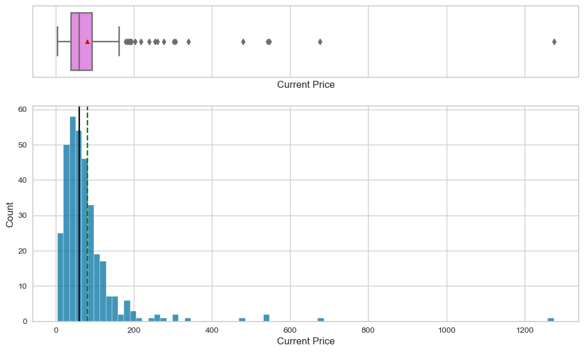

```python
#Histogram and Boxplot of 'Current Price'
histogram_boxplot(df, 'Current Price')
```

#### Observations

- Current Price is skewed to the right with many outliers to the right
- Current Price is in part determined by the number of shares outstanding
  - As this can be adjusted by the corporation, the right skew should not be a problem
  - Some companies will issue more shares to lower the price per share, for example

#### Price Change

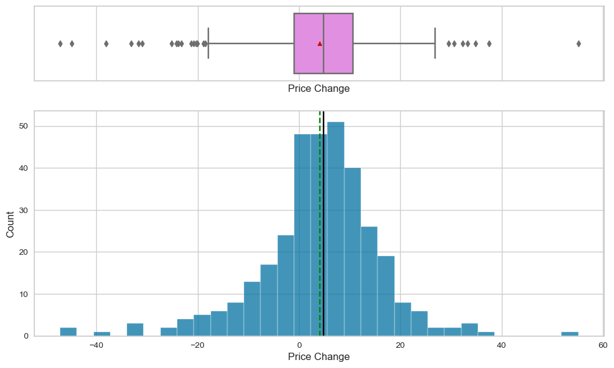

```python
#Histogram and Boxplot of 'Price Change'
histogram_boxplot(df, 'Price Change')
```

#### Observations

- Price Change over the past 13 weeks appears to be approximately normally distributed
- Mean and median are close, indicating low skewness

#### 2. The stocks of which economic sector have seen the maximum price increase on average?

```python
#Group by GICS Sector and find average price increase
pricechange_sector = df.groupby("GICS Sector")["Price Change"].mean()
pricechange_sector = pd.DataFrame(pricechange_sector)
pricechange_sector = pricechange_sector.sort_values("Price Change", ascending = False)
print(pricechange_sector)
```

```
                             Price Change
GICS Sector
Health Care                      9.585652
Consumer Staples                 8.684750
Information Technology           7.217476
Telecommunications Services      6.956980
Real Estate                      6.205548
Consumer Discretionary           5.846093
Materials                        5.589738
Financials                       3.865406
Industrials                      2.833127
Utilities                        0.803657
Energy                         -10.228289
```

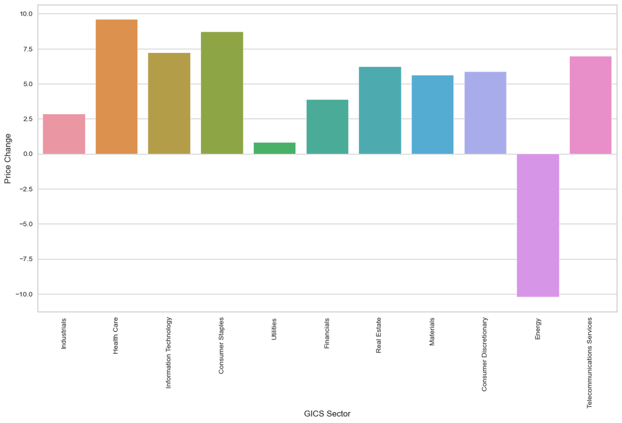

```python
plt.figure(figsize=(15,8))
sns.barplot(data=df, x='GICS Sector', y='Price Change', ci=False)
plt.xticks(rotation=90)
plt.show()
```

#### Observations

- Health Care had the highest percentage price increase on average over the past 13 weeks at 9.59%
  - Consumer Staples had the second highest percentage increase on average at 8.68%
  - Information Technology had the third highest percentage increase on average at 7.22%
- Energy had the lowest percentage price change on average over the past 13 weeks at -10.23%

#### Volatility

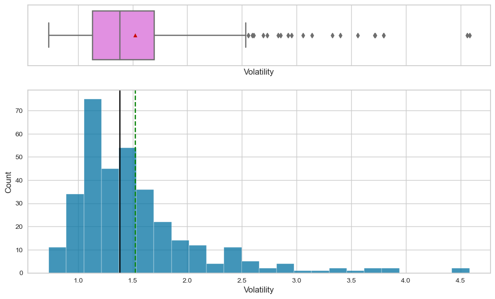

```python
#Histogram and Boxplot of 'Volatility'
histogram_boxplot(df, 'Volatility')
```

#### Observations

- Volatility is skewed to the right
- Volatility is equal to standard deviation of stock price per share over the past 13 weeks
  - Since it is influenced by the magnitude of stock price per share, and we know Current Price is skewed right, this should not be a problem
  - Volatility could be scaled by stock price, but it will be kept as is for the subsequent analysis

#### ROE

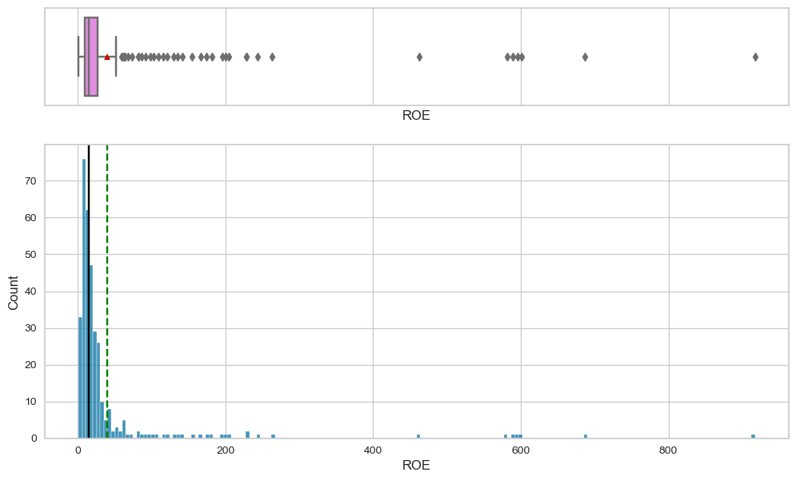

```python
#Histogram and Boxplot of 'ROE'
histogram_boxplot(df, 'ROE')
```

```python
#Check ROE
df['ROE'].describe()
```

```
count    340.000000
mean      39.597059
std       96.547538
min        1.000000
25%        9.750000
50%       15.000000
75%       27.000000
max      917.000000
Name: ROE, dtype: float64
```

#### Observations

- ROE is highly skewed to the right
  - This can be influenced by the denominator, Shareholders' Equity
- Also, the minimum ROE is 1%
  - A negative Net Income would result in a negative ROE, so it would be good to verify this data is correct
  - However, to proceed with the analysis, it is assumed to be correct

#### Cash Ratio

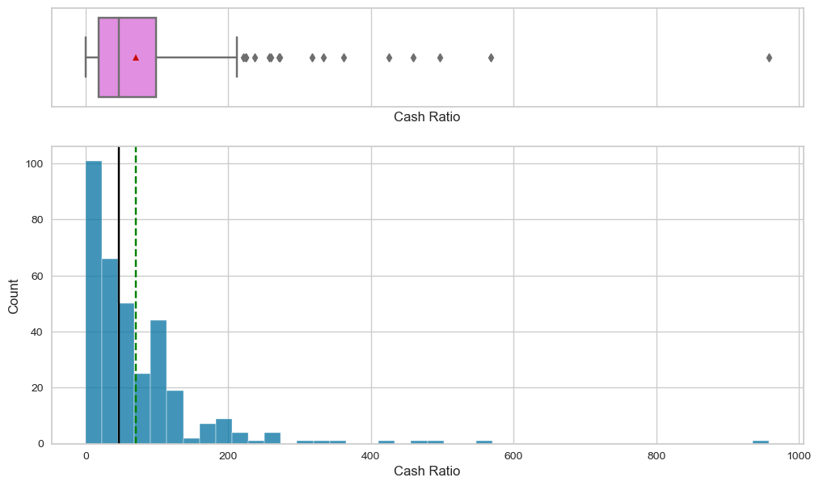

```python
#Histogram and Boxplot of 'Cash Ratio'
histogram_boxplot(df, 'Cash Ratio')
```

#### Observations

- Cash Ratio is also highly skewed to the right with a number of outliers as well
- The calculation is Cash and Cash Equivalents / Total Current Liabilities
  - Companies with low Total Current Liabilities could be, in part, driving the right skew and outliers

#### Net Cash Flow

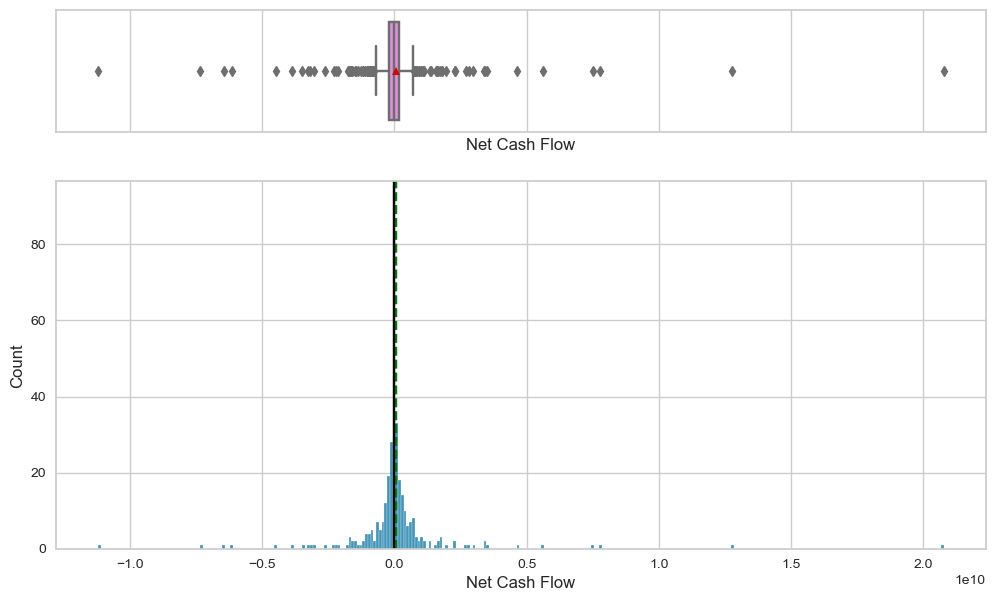

```python
#Histogram and Boxplot of 'Net Cash Flow'
histogram_boxplot(df, 'Net Cash Flow')
```

```python
df['Net Cash Flow'].describe()
```

```
count    3.400000e+02
mean     5.553762e+07
std      1.946365e+09
min     -1.120800e+10
25%     -1.939065e+08
50%      2.098000e+06
75%      1.698108e+08
max      2.076400e+10
Name: Net Cash Flow, dtype: float64
```

#### Observations

- Net Cash Flow appears to be approximately normally distributed with a number of outliers to the left and right
- The outliers are likely associated with larger companies as the variable is given in dollars, and is not as a percentage
- Net Cash Flow could be scaled by some measure of company size, but will be kept for the subsequent analysis

#### Net Income

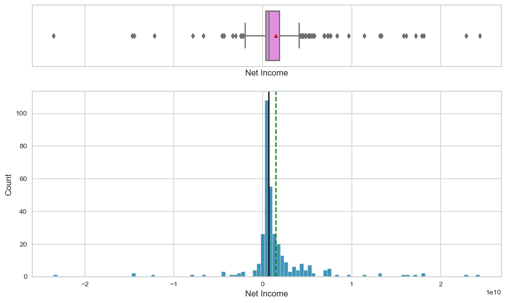

```python
#Histogram and Boxplot of 'Net Income'
histogram_boxplot(df, 'Net Income')
```

#### Observations

- Net Income appears to be somewhat skewed right with a number of outliers to the left and right
- The outliers are likely associated with larger companies as the variable is given in dollars, and is not as a percentage
- This field could also be scaled by some measure of company size

#### Earnings Per Share

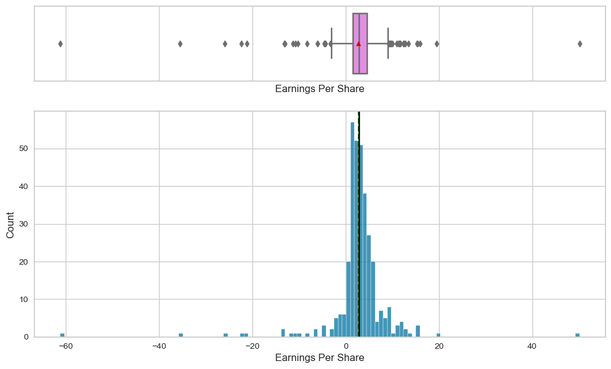

```python
#Histogram and Boxplot of 'Earnings Per Share'
histogram_boxplot(df, 'Earnings Per Share')
```

#### Observations

- Earnings Per Share has a number of outliers to the left and right
- The outliers should not be a concern as earnings vary considerably between companies, as does the number of shares outstanding

#### Estimated Shares Outstanding

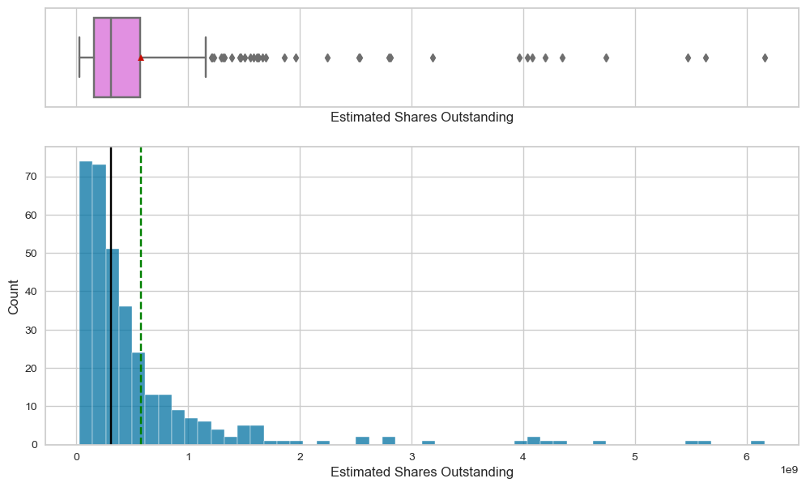

```python
#Histogram and Boxplot of 'Estimated Shares Outstanding'
histogram_boxplot(df, 'Estimated Shares Outstanding')
```

```python
df['Estimated Shares Outstanding'].describe()
```

```
count    3.400000e+02
mean     5.770283e+08
std      8.458496e+08
min      2.767216e+07
25%      1.588482e+08
50%      3.096751e+08
75%      5.731175e+08
max      6.159292e+09
Name: Estimated Shares Outstanding, dtype: float64
```

#### Observations

- Estimated Shares Outstanding cannot be negative, as is shown
- There are a number of outliers to the right
- As Estimated Shares Outstanding is influenced by company decisions and company size, the outliers should not be a concern

#### P/E Ratio

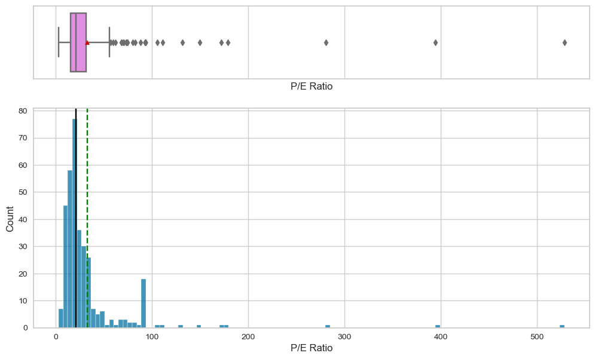

```python
#Histogram and Boxplot of 'P/E Ratio'
histogram_boxplot(df, 'P/E Ratio')
```

```python
df['P/E Ratio'].describe()
```

```
count    340.000000
mean      32.612563
std       44.348731
min        2.935451
25%       15.044653
50%       20.819876
75%       31.764755
max      528.039074
Name: P/E Ratio, dtype: float64
```

#### Observations

- The minimum P/E Ratio is 2.94
  - However, Net Income was in some cases negative, which would make P/E Ratio also negative
  - It would be best to do RCA on this, but analysis will be done assuming there are no errors
- P/E Ratio is skewed right with many outliers to the right
  - This can be caused in some cases by very low positive earnings

#### P/B Ratio

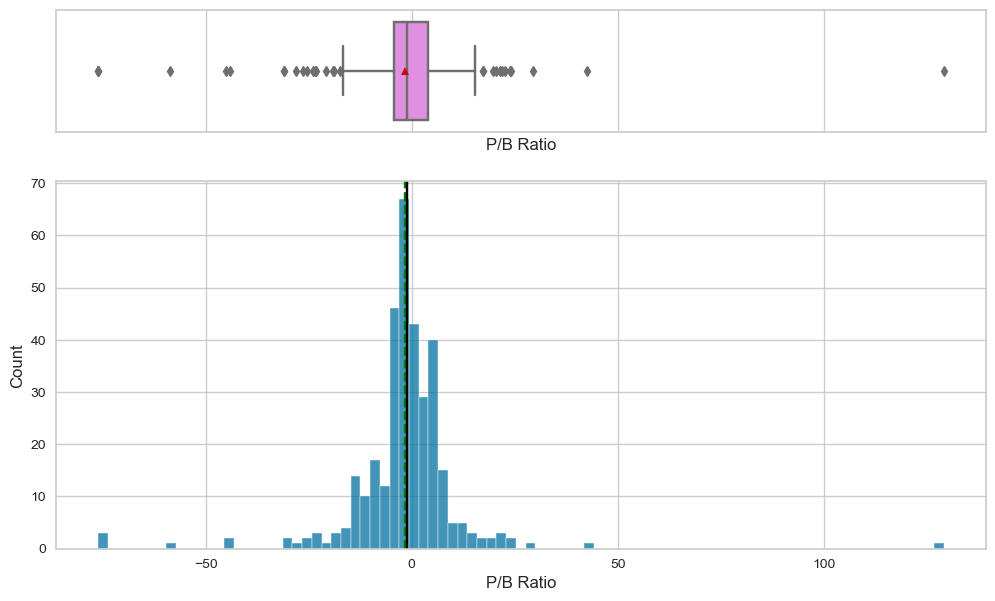

```python
#Histogram and Boxplot of 'P/B Ratio'
histogram_boxplot(df, 'P/B Ratio')
```

#### Observations

- P/B Ratio is generally symmetrical with mean and median values shown to be very similar
- Negative values for P/B Ratio are acceptable when book value per share is negative
- Outliers may be partly the result of book value per share that is low in magnitude

#### Create a Function for Creating Barplots for Non-Numerical Variables

```python
def labeled_barplot(df, feature, perc=False, n=None):
    """
    Barplot with percentage at the top

    data: dataframe
    feature: dataframe column
    perc: whether to display percentages instead of count (default is False)
    n: displays the top n category levels (default is None, i.e., display all levels)
    """

    total = len(df[feature])  # length of the column
    count = df[feature].nunique()
    if n is None:
        plt.figure(figsize=(count + 1, 5))
    else:
        plt.figure(figsize=(n + 1, 5))

    plt.xticks(rotation=90, fontsize=15)
    ax = sns.countplot(
        data=df,
        x=feature,
        palette="Paired",
        order=df[feature].value_counts().index[:n].sort_values(),
    )

    for p in ax.patches:
        if perc == True:
            label = "{:.1f}%".format(
                100 * p.get_height() / total
            )  # percentage of each class of the category
        else:
            label = p.get_height()  # count of each level of the category

        x = p.get_x() + p.get_width() / 2  # width of the plot
        y = p.get_height()  # height of the plot

        ax.annotate(
            label,
            (x, y),
            ha="center",
            va="center",
            size=12,
            xytext=(0, 5),
            textcoords="offset points",
        )  # annotate the percentage

    plt.show()
```

#### CIGS Sector

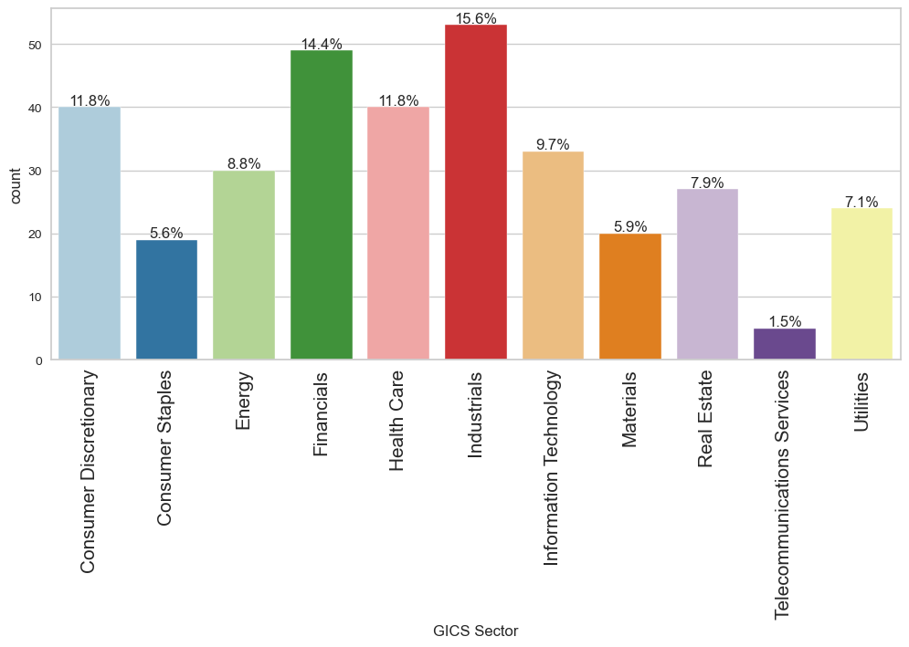

```python
labeled_barplot(df, 'GICS Sector', perc=True)
```

#### Observations

- Industrials and Financials make up the largest percentage of observations at 15.6% and 14.4%, respectively
- Telecommunications Services makes up the smallest percentage of observations at 1.5%

#### CIGS Sub Industry

[figure not shown]

```python
labeled_barplot(df, 'GICS Sub Industry', perc=True)
```

```python
df['GICS Sub Industry'].nunique()
```

```
104
```

#### Observations

- Analysis across GICS Sector is likely preferred to analysis across GICS Sub Industry as there are 104 different sub-industries

### Bivariate Analysis

#### Correlation Between Numerical Columns

#### 3. How are the different variables correlated with each other?

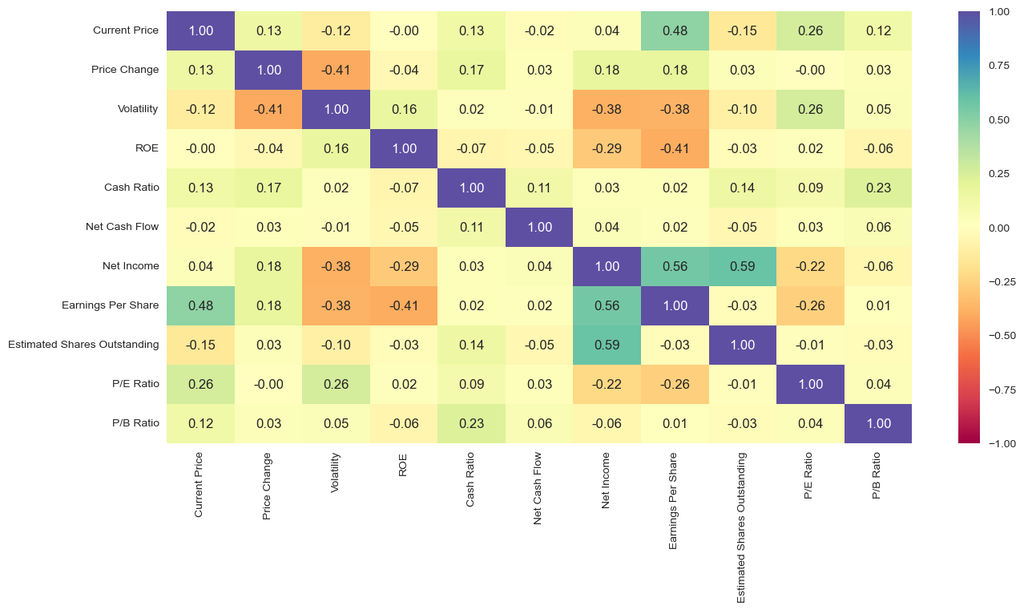

```python
#Find correlation
plt.figure(figsize=(15, 7))
sns.heatmap(df.corr(), annot=True, vmin=-1, vmax=1, fmt=".2f", cmap="Spectral")
plt.show()
```

#### Observations

- Estimated Shares Outstanding is positively correlated with Net Income at 0.59
  - This may partly reflect the fact that larger firms have more shares and also generate more income in dollars
- Earnings Per Share is positively correlated with Net Income at 0.56
  - This correlation makes sense intuitively
- ROE and Earnings Per Share have the largest negative correlation at -0.41
  - This is somewhat counterintuitive
  - ROE was found to always be positive although Net Income is frequently negative
- Volatility and Earnings Per Share are also found to have a negative correlation at -0.38
  - This may partly reflect that more stable and mature companies have lower volatility and higher earnings in dollars since they are likley larger

#### 4. How does the average cash ratio vary across economic sectors?

```python
#Group by GICS Sector and find average Cash Ratio
cashratio_sector = df.groupby("GICS Sector")["Cash Ratio"].mean()
cashratio_sector = pd.DataFrame(cashratio_sector)
cashratio_sector = cashratio_sector.sort_values("Cash Ratio", ascending = False)
print(cashratio_sector)
```

```
                             Cash Ratio
GICS Sector
Information Technology       149.818182
Telecommunications Services  117.000000
Health Care                  103.775000
Financials                    98.591837
Consumer Staples              70.947368
Energy                        51.133333
Real Estate                   50.111111
Consumer Discretionary        49.575000
Materials                     41.700000
Industrials                   36.188679
Utilities                     13.625000
```

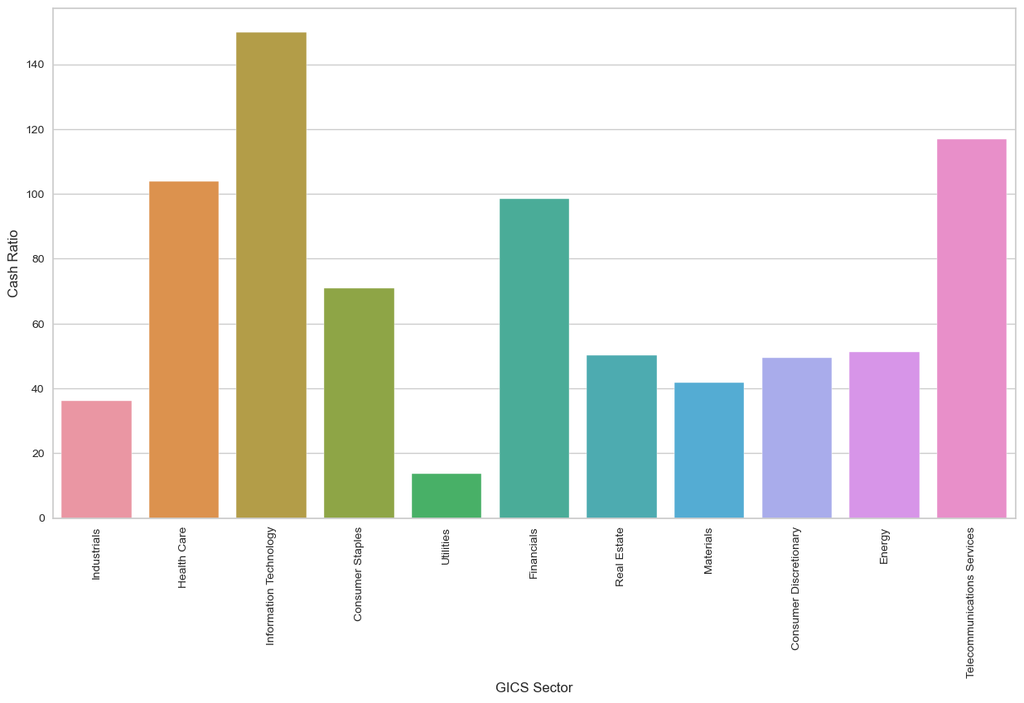

```python
#Barplot of 'Cash Ratio' by "GICS Sector"
plt.figure(figsize=(15,8))
sns.barplot(data=df, x='GICS Sector', y='Cash Ratio', ci=False)
plt.xticks(rotation=90)
plt.show()
```

#### Observations

- Information Technology has the highest average Cash Ratio at 149.8 (reported as a percentage)
  - Telecommunication Services has the second highest at 117.0
- Utilities has the lowest average Cash Ratio at 13.6
- These observations may indicate that companies in riskier industries tend to hold more cash and cash equivalents

#### 5. How does the P/E ratio vary, on average, across economic sectors?

```python
#Group by GICS Sector and find average P/E Ratio
PEratio_sector = df.groupby("GICS Sector")["P/E Ratio"].mean()
PEratio_sector = pd.DataFrame(PEratio_sector)
PEratio_sector = PEratio_sector.sort_values("P/E Ratio", ascending = False)
print(PEratio_sector)
```

```
                             P/E Ratio
GICS Sector
Energy                       72.897709
Information Technology       43.782546
Real Estate                  43.065585
Health Care                  41.135272
Consumer Discretionary       35.211613
Consumer Staples             25.521195
Materials                    24.585352
Utilities                    18.719412
Industrials                  18.259380
Financials                   16.023151
Telecommunications Services  12.222578
```

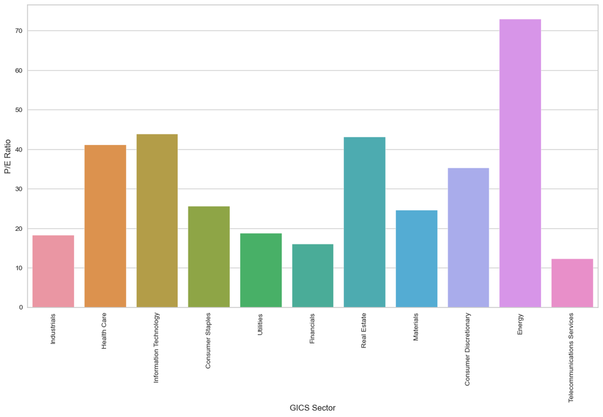

```python
#Barplot of 'P/E Ratio' by "GICS Sector"
plt.figure(figsize=(15,8))
sns.barplot(data=df, x='GICS Sector', y='P/E Ratio', ci=False)
plt.xticks(rotation=90)
plt.show()
```

#### Observations

- Energy has the highest average P/E Ratio at 72.9
  - Information Technology and Real Estate have the second and third highest average P/E Ratio at 43.8 and 43.1, respectively
- Telecommunications Services has the lowest average P/E Ratio at 12.2

#### Average Volatility by Economic Sector

```python
#Group by GICS Sector and find average Volatility
volatility_sector = df.groupby("GICS Sector")["Volatility"].mean()
volatility_sector = pd.DataFrame(volatility_sector)
volatility_sector = volatility_sector.sort_values("Volatility", ascending = False)
print(volatility_sector)
```

```
                             Volatility
GICS Sector
Energy                         2.568777
Materials                      1.816726
Information Technology         1.659801
Consumer Discretionary         1.595478
Health Care                    1.541023
Industrials                    1.416989
Telecommunications Services    1.341612
Financials                     1.267255
Real Estate                    1.206053
Consumer Staples               1.152675
Utilities                      1.118018
```

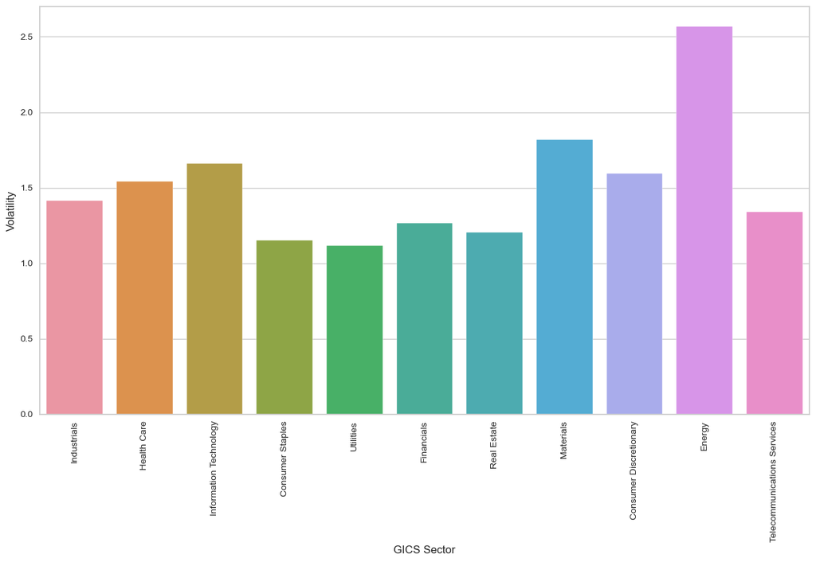

```python
#Barplot of 'Volatility' by "GICS Sector"
plt.figure(figsize=(15,8))
sns.barplot(data=df, x='GICS Sector', y='Volatility', ci=False)
plt.xticks(rotation=90)
plt.show()
```

#### Observations

- Energy has the highest average Volatility at 2.57
  - Energy stocks are influenced by energy prices which are often volatile
- Utilities has the lowest average Volatility at 1.12
  - Utilities are generally considered safe, so low Volatility is consistent with this

## Data Preprocessing

- Duplicate value check - no duplicate rows found
- Missing value treatment - no missing values found
- Outlier check - outliers will not be treated
- Feature engineering - all variables will be scaled
- Any other preprocessing steps - none

#### Duplicate Value Check

```python
df.duplicated().sum()
```

```
0
```

#### Missing Value Check

```python
df.isnull().sum()
```

```
Ticker Symbol                   0
Security                        0
GICS Sector                     0
GICS Sub Industry               0
Current Price                   0
Price Change                    0
Volatility                      0
ROE                             0
Cash Ratio                      0
Net Cash Flow                   0
Net Income                      0
Earnings Per Share              0
Estimated Shares Outstanding    0
P/E Ratio                       0
P/B Ratio                       0
dtype: int64
```

#### Observations

- No duplicate rows are found in the DataFrame, so no action is needed
- No missing values are found for any of the columns, so no action is needed

#### Outlier Check

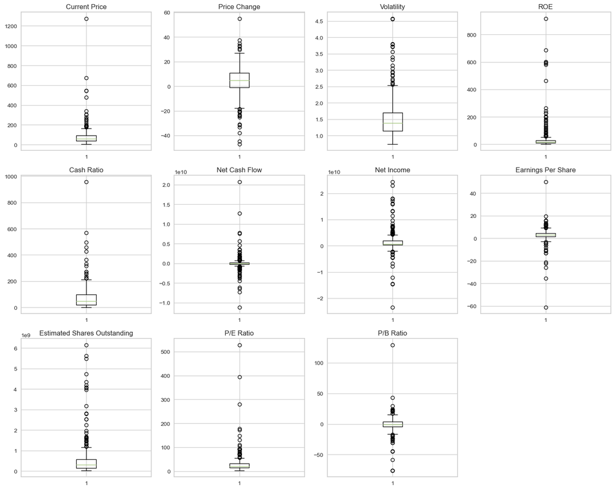

```python
#Boxplots of all numerical columns
plt.figure(figsize=(15, 12))

numeric_columns = df.select_dtypes(include=np.number).columns.tolist()

for i, variable in enumerate(numeric_columns):
    plt.subplot(3, 4, i + 1)
    plt.boxplot(df[variable], whis=1.5)
    plt.tight_layout()
    plt.title(variable)

plt.show()
```

#### Observations

- Current Price has many outliers to the right, however, price per share is influenced by number of shares outstanding
  - For example, if shares are retired, Current Price will increase mechanically
  - No outlier treatment will be performed
- Price Change over the past 13 weeks appears to be approximately normally distributed with outliers to the left and right
  - No outlier treatment will be performed
- Volatility has many outliers to the right, however, this can be impacted by the scale of Current Price
  - No outlier treatment will be performed
- ROE has many outliers to the right, however, these can be influenced by the size of the denominator, book value of equity
  - One potential issue is that there are no observations with negative ROE, which should occur with negative net income and positive book value of equity
  - RCA should be performed, however, in subsequent analysis the values for ROE will be assumed to be correct
  - No outlier treatment will be performed
- Cash Ratio also has many right hand outliers, however, this can result with low Total Current Liabilities
  - No outlier treatment will be performed
- Net Cash Flow has many outliers to the left and to the right, however, larger magnitudes are more likely to be associated with large companies
  - The outliers are reasonable as the variable is given in dollars, and not as a percentage
  - No outlier treatment will be performed
- Net Income has many outliers to the left and to the right, however, larger magnitudes are more likely to be associated with large companies
  - The outliers are reasonable as the variable is given in dollars, and not as a percentage
  - No outlier treatment will be performed
- Earnings Per Share has a number of outliers to the left and right
  - The outliers are reasonable as EPS varies considerably among companies, as does the number of shares outstanding
  - No outlier treatment will be performed
- Estimated Shares Outstanding has many outliers to the right
  - The values are reasonable and are likely influenced by company size and the discretion of company management
  - No outlier treatment will be performed
- P/E Ratio has many outliers to the right
  - This can be a result of low positive earnings
  - However, Net Income was in some cases negative, which would make P/E Ratio also negative
  - RCA should be performed, however, in subsequent analysis the values for P/E Ratio will be assumed to be correct
  - No outlier treatment will be performed
- P/B Ratio has many outliers to the right and to the left
  - Negative values for P/B Ratio are acceptable when book value per share is negative
  - Outliers may be partly the result of book value of equity that is low in magnitude
  - No outlier treatment will be performed

##### Although ROE and P/E Ratio only have positive values, these values will be assumed to be correct for subsequent analysis

##### It is otherwise reasonable for all of the variables to have outliers, so no outlier treatment will be performed on any of the variables

#### Scaling the Data

```python
subset = df.iloc[:,4:]
subsetScaled = subset.apply(zscore)
subsetScaled.head()
```

|  | Current Price | Price Change | Volatility | ROE | Cash Ratio | Net Cash Flow | Net Income | Earnings Per Share | Estimated Shares Outstanding | P/E Ratio | P/B Ratio |
| --- | --- | --- | --- | --- | --- | --- | --- | --- | --- | --- | --- |
| 0 | -0.393341 | 0.493950 | 0.272749 | 0.989601 | -0.210698 | -0.339355 | 1.554415 | 1.309399 | 0.107863 | -0.652487 | -0.506653 |
| 1 | -0.220837 | 0.355439 | 1.137045 | 0.937737 | 0.077269 | -0.002335 | 0.927628 | 0.056755 | 1.250274 | -0.311769 | -0.504205 |
| 2 | -0.367195 | 0.602479 | -0.427007 | -0.192905 | -0.033488 | 0.454058 | 0.744371 | 0.024831 | 1.098021 | -0.391502 | 0.094941 |
| 3 | 0.133567 | 0.825696 | -0.284802 | -0.317379 | 1.218059 | -0.152497 | -0.219816 | -0.230563 | -0.091622 | 0.947148 | 0.424333 |
| 4 | -0.260874 | -0.492636 | 0.296470 | -0.265515 | 2.237018 | 0.133564 | -0.202703 | -0.374982 | 1.978399 | 3.293307 | 0.199196 |

## Exploratory Data Analysis Check

- No adjustments were made to the data other than scaling, so additonal EDA is not performed

## K-means Clustering

```python
#Create copy of df (including non-numeric variables) and subsetScaled (excluding non-numeric variables / scaled)
df1 = df.copy()
k_means_df = subsetScaled.copy()
```

### Create Elbow Plot

#### Distortion Scores with KElbowVisualizer

```
Number of Clusters: 1 	Average Distortion: 2.5425069919221697
Number of Clusters: 2 	Average Distortion: 2.382318498894466
Number of Clusters: 3 	Average Distortion: 2.2692367155390745
Number of Clusters: 4 	Average Distortion: 2.1745559827866363
Number of Clusters: 5 	Average Distortion: 2.128799332840716
Number of Clusters: 6 	Average Distortion: 2.080400099226289
Number of Clusters: 7 	Average Distortion: 2.0289794220177395
Number of Clusters: 8 	Average Distortion: 1.964144163389972
```

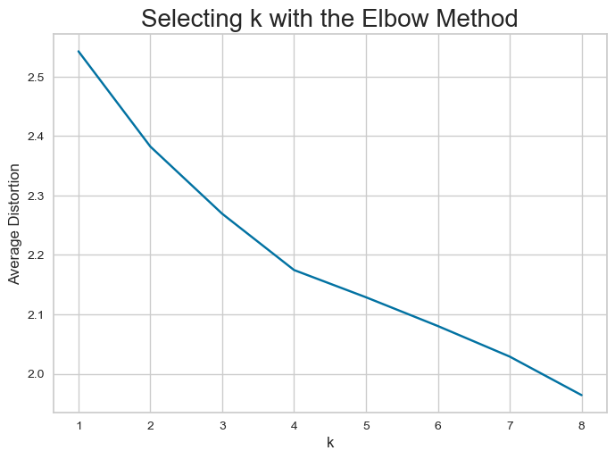

```python
#Check number of clusters from 1 to 8
clusters = range(1, 9)
meanDistortions = []

for k in clusters:
    model = KMeans(n_clusters=k, random_state=1)
    model.fit(subsetScaled)
    prediction = model.predict(k_means_df)
    distortion = (
        sum(np.min(cdist(k_means_df, model.cluster_centers_, "euclidean"), axis=1))
        / k_means_df.shape[0]
    )

    meanDistortions.append(distortion)

    print("Number of Clusters:", k, "\tAverage Distortion:", distortion)

plt.plot(clusters, meanDistortions, "bx-")
plt.xlabel("k")
plt.ylabel("Average Distortion")
plt.title("Selecting k with the Elbow Method", fontsize=20)
plt.show()
```

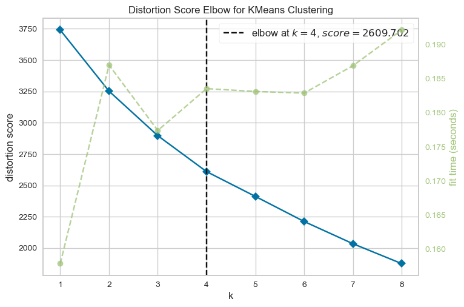

```python
#Check number of clusters from 1 through 8 using distortion score
model = KMeans(random_state=1)
visualizer = KElbowVisualizer(model, k=(1, 9), timings=True)
visualizer.fit(k_means_df)
visualizer.show()
```

#### Observations

- Average Distortion / Distortion Score declines relatively rapidly as k increases until 4, which is the appropriate value based on this analysis

#### Silhouette Scores

```
For n_clusters = 2, the silhouette score is 0.43969639509980457)
For n_clusters = 3, the silhouette score is 0.4644405674779404)
For n_clusters = 4, the silhouette score is 0.4577225970476733)
For n_clusters = 5, the silhouette score is 0.43228336443659804)
For n_clusters = 6, the silhouette score is 0.4005422737213617)
For n_clusters = 7, the silhouette score is 0.3976335364987305)
For n_clusters = 8, the silhouette score is 0.40278401969450467)
```

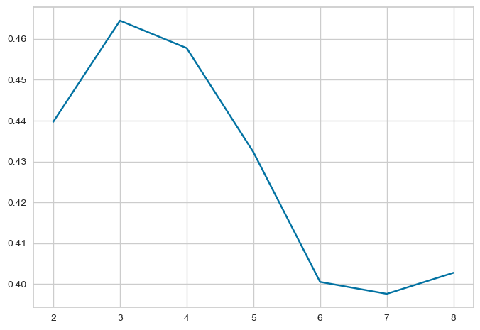

```python
#Return Silhouette Scores
sil_score = []
cluster_list = range(2, 9)
for n_clusters in cluster_list:
    clusterer = KMeans(n_clusters=n_clusters, random_state=1)
    preds = clusterer.fit_predict((subsetScaled))
    score = silhouette_score(k_means_df, preds)
    sil_score.append(score)
    print("For n_clusters = {}, the silhouette score is {})".format(n_clusters, score))

plt.plot(cluster_list, sil_score)
plt.show()
```

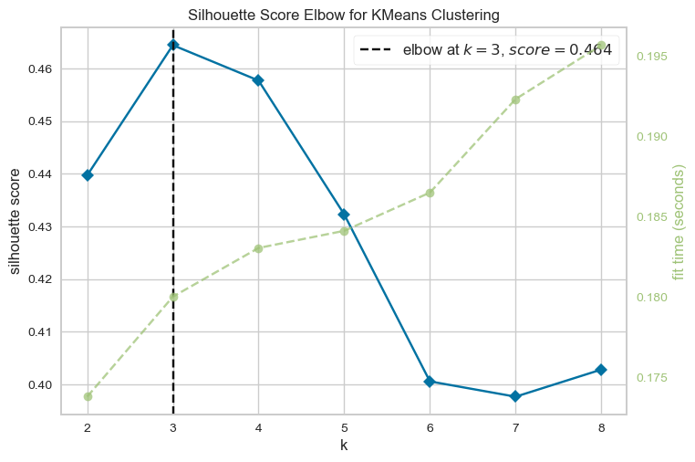

```python
#Check number of clusters from 2 through 8 using silhouette score
model = KMeans(random_state=1)
visualizer = KElbowVisualizer(model, k=(2, 9), metric="silhouette", timings=True)
visualizer.fit(k_means_df)
visualizer.show()
```

#### Observations

- Silhouette score is greatest at 3 clusters at 0.464
- However, with 4 clusters Silhouette score is not much lower at 0.458

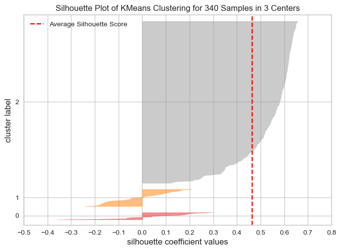

```python
# Create Silhouette Plot with 3 clusters
visualizer = SilhouetteVisualizer(KMeans(n_clusters = 3, random_state=1))
visualizer.fit(k_means_df)
visualizer.show()
```

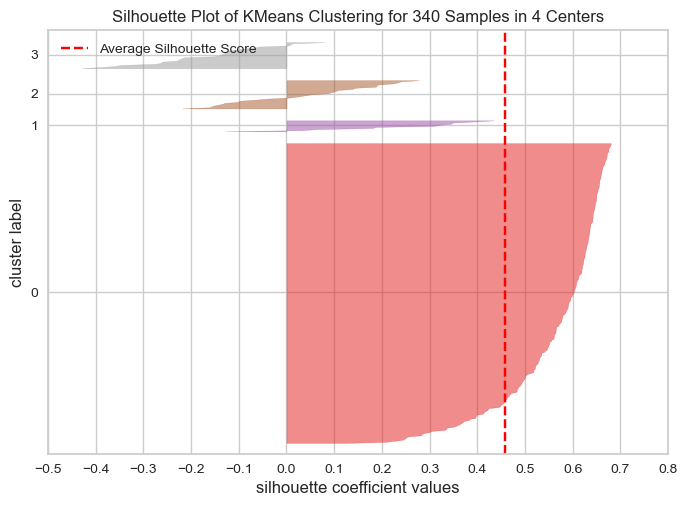

```python
# Create Silhouette Plot with 4 clusters
visualizer = SilhouetteVisualizer(KMeans(n_clusters = 4, random_state=1))
visualizer.fit(k_means_df)
visualizer.show()
```

#### Observations

- Based on Distortion, 4 clusters is indicated as the optimal number of clusters
- Based on Silhouette Score, 3 clusters is indicated as the optimal number of clusters
  - However, Silhouette Score is not much smaller for 4 clusters
- Based on the Silhouette plots, 4 clusters appears to be better than 3
  - For 3 clusters, Cluster 0 and Cluster 1 have Silhouette Scores considerably less than the overall average
  - For 4 clusters, Cluster 1 is near the average and Cluster 2 is not dramatically less than the overall average
  - For both 3 and 4 clusters, one cluster - Cluster 2 and Cluster 0, respectively - is substantially larger than the others
- Given these findings, 4 clusters will be chosen for subsequent analysis

### Final K-means Model

```python
#Create final K-means Model
final_kmeans = KMeans(n_clusters=4, random_state=1)
final_kmeans.fit(k_means_df)
```

```
KMeans(n_clusters=4, random_state=1)
```

```python
#Add labels to df1 (includes non-numerical columns) and k_means_df (only scaled numerical columns)
df1['Cluster'] = final_kmeans.labels_
k_means_df['Cluster'] = final_kmeans.labels_
```

### Cluster Profiling

```python
#Create cluster_profile with mean values by cluster based on original non-scaled data
cluster_profile = df1.groupby("Cluster").mean()
```

```python
#Add Count variable to cluster_profile
cluster_profile['Count'] = df1.groupby("Cluster")['Security'].count().values
```

```python
#View cluster_profile highlighting the highest average values for each variable
cluster_profile.style.highlight_max(color = "lightblue", axis = 0)
```

| Cluster | Current Price | Price Change | Volatility | ROE | Cash Ratio | Net Cash Flow | Net Income | Earnings Per Share | Estimated Shares Outstanding | P/E Ratio | P/B Ratio | Count |
| --- | --- | --- | --- | --- | --- | --- | --- | --- | --- | --- | --- | --- |
| 0 | 72.399112 | 5.066225 | 1.388319 | 34.620939 | 53.000000 | -14046223.826715 | 1482212389.891697 | 3.621029 | 438533835.667184 | 23.843656 | -3.358948 | 277 |
| 1 | 50.517273 | 5.747586 | 1.130399 | 31.090909 | 75.909091 | -1072272727.272727 | 14833090909.090910 | 4.154545 | 4298826628.727273 | 14.803577 | -4.552119 | 11 |
| 2 | 38.099260 | -15.370329 | 2.910500 | 107.074074 | 50.037037 | -159428481.481481 | -3887457740.740741 | -9.473704 | 480398572.845926 | 90.619220 | 1.342067 | 27 |
| 3 | 234.170932 | 13.400685 | 1.729989 | 25.600000 | 277.640000 | 1554926560.000000 | 1572611680.000000 | 6.045200 | 578316318.948800 | 74.960824 | 14.402452 | 25 |

```python
#Identify the companies within each cluster
for cl in df1['Cluster'].unique():
    print("Cluster {} includes:".format(cl))
    print(df1[df1['Cluster'] == cl]["Security"].unique())
    print()
```

```
Cluster 0 includes:
['American Airlines Group' 'AbbVie' 'Abbott Laboratories'
 'Adobe Systems Inc' 'Archer-Daniels-Midland Co' 'Ameren Corp'
 'American Electric Power' 'AFLAC Inc'
 'American International Group, Inc.' 'Apartment Investment & Mgmt'
 'Assurant Inc' 'Arthur J. Gallagher & Co.' 'Akamai Technologies Inc'
 'Albemarle Corp' 'Alaska Air Group Inc' 'Allstate Corp' 'Allegion'
 'Applied Materials Inc' 'AMETEK Inc' 'Affiliated Managers Group Inc'
 'Ameriprise Financial' 'American Tower Corp A' 'AutoNation Inc'
 'Anthem Inc.' 'Aon plc' 'Amphenol Corp' 'Arconic Inc'
 'Activision Blizzard' 'AvalonBay Communities, Inc.' 'Broadcom'
 'American Water Works Company Inc' 'American Express Co' 'Boeing Company'
 'Baxter International Inc.' 'BB&T Corporation' 'Bard (C.R.) Inc.'
 'The Bank of New York Mellon Corp.' 'Ball Corp' 'Bristol-Myers Squibb'
 'Boston Scientific' 'BorgWarner' 'Boston Properties' 'Caterpillar Inc.'
 'Chubb Limited' 'CBRE Group' 'Crown Castle International Corp.'
 'Carnival Corp.' 'CF Industries Holdings Inc' 'Citizens Financial Group'
 'Church & Dwight' 'C. H. Robinson Worldwide' 'Charter Communications'
 'CIGNA Corp.' 'Cincinnati Financial' 'Colgate-Palmolive' 'Comerica Inc.'
 'CME Group Inc.' 'Cummins Inc.' 'CMS Energy' 'Centene Corporation'
 'CenterPoint Energy' 'Capital One Financial' 'The Cooper Companies'
 'CSX Corp.' 'CenturyLink Inc' 'Cognizant Technology Solutions'
 'Citrix Systems' 'CVS Health' 'Chevron Corp.' 'Dominion Resources'
 'Delta Air Lines' 'Du Pont (E.I.)' 'Deere & Co.'
 'Discover Financial Services' 'Quest Diagnostics' 'Danaher Corp.'
 'The Walt Disney Company' 'Discovery Communications-A'
 'Discovery Communications-C' 'Delphi Automotive' 'Digital Realty Trust'
 'Dun & Bradstreet' 'Dover Corp.' 'Dr Pepper Snapple Group' 'Duke Energy'
 'DaVita Inc.' 'eBay Inc.' 'Ecolab Inc.' 'Consolidated Edison'
 'Equifax Inc.' "Edison Int'l" 'Eastman Chemical' 'Equity Residential'
 'Eversource Energy' 'Essex Property Trust, Inc.' 'E*Trade'
 'Eaton Corporation' 'Entergy Corp.' 'Exelon Corp.' "Expeditors Int'l"
 'Expedia Inc.' 'Extra Space Storage' 'Fastenal Co'
 'Fortune Brands Home & Security' 'FirstEnergy Corp'
 'Fidelity National Information Services' 'Fiserv Inc' 'FLIR Systems'
 'Fluor Corp.' 'Flowserve Corporation' 'FMC Corporation'
 'Federal Realty Investment Trust' 'General Dynamics'
 'General Growth Properties Inc.' 'Corning Inc.' 'General Motors'
 'Genuine Parts' 'Garmin Ltd.' 'Goodyear Tire & Rubber'
 'Grainger (W.W.) Inc.' 'Hasbro Inc.' 'Huntington Bancshares'
```

[output cut: 58 more lines]

```
Cluster 2 includes:
['Apache Corporation' 'Anadarko Petroleum Corp' 'Baker Hughes Inc'
 'Chesapeake Energy' 'Cabot Oil & Gas' 'Concho Resources'
 'Devon Energy Corp.' 'EOG Resources' 'EQT Corporation'
 'Freeport-McMoran Cp & Gld' 'Hess Corporation'
 'Hewlett Packard Enterprise' 'Kinder Morgan' 'Marathon Oil Corp.'
 'Murphy Oil' 'Noble Energy Inc' 'Netflix Inc.' 'Newfield Exploration Co'
 'National Oilwell Varco Inc.' 'ONEOK' 'Occidental Petroleum'
 'Quanta Services Inc.' 'Range Resources Corp.' 'Southwestern Energy'
 'Teradata Corp.' 'Williams Cos.' 'Cimarex Energy']

Cluster 1 includes:
['Citigroup Inc.' 'Ford Motor' 'Gilead Sciences' 'Intel Corp.'
 'JPMorgan Chase & Co.' 'Coca Cola Company' 'Pfizer Inc.' 'AT&T Inc'
 'Verizon Communications' 'Wells Fargo' 'Exxon Mobil Corp.']
```

```python
#Number of companies within each cluster
df1.groupby(['Cluster'])['Security'].count()
```

```
Cluster
0    277
1     11
2     27
3     25
Name: Security, dtype: int64
```

```python
#For each cluster, find the number of companies from each GICS Sector
df1.groupby(['Cluster', 'GICS Sector'])['Security'].count()
```

```
Cluster  GICS Sector
0        Consumer Discretionary         33
         Consumer Staples               17
         Energy                          6
         Financials                     45
         Health Care                    29
         Industrials                    52
         Information Technology         24
         Materials                      19
         Real Estate                    26
         Telecommunications Services     2
         Utilities                      24
1        Consumer Discretionary          1
         Consumer Staples                1
         Energy                          1
         Financials                      3
         Health Care                     2
         Information Technology          1
         Telecommunications Services     2
2        Energy                         22
         Industrials                     1
         Information Technology          3
         Materials                       1
3        Consumer Discretionary          6
         Consumer Staples                1
         Energy                          1
         Financials                      1
         Health Care                     9
         Information Technology          5
         Real Estate                     1
         Telecommunications Services     1
Name: Security, dtype: int64
```

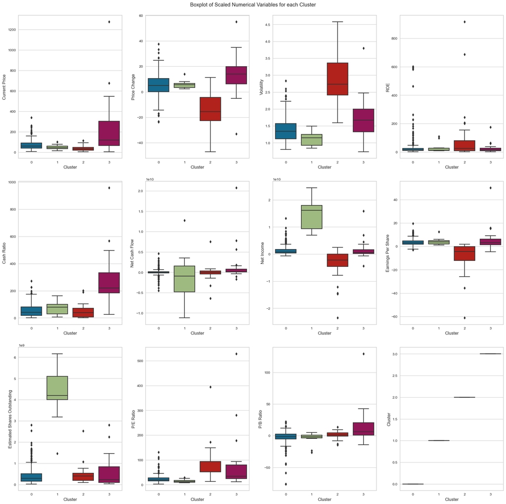

```python
#Create boxplots by cluster for numerical variables
plt.figure(figsize=(20, 20))
plt.suptitle("Boxplot of Scaled Numerical Variables for each Cluster")

# selecting numerical columns
num_col = df1.select_dtypes(include=np.number).columns.tolist()

for i, variable in enumerate(num_col):
    plt.subplot(3, 4, i + 1)
    sns.boxplot(data=df1, x="Cluster", y=variable)

plt.tight_layout(pad=2.0)
```

## Hierarchical Clustering

```python
#Create copy of df (including non-numeric variables) and subsetScaled (excluding non-numeric variables / scaled)
df2 = df.copy()
hc_df = subsetScaled.copy()
```

### Check distance metric and linkage method resulting in highest Cophenetic Correlation

```python
# Find combination of distance metric and linkage method that results in the greatest cophenetic correlation

# list of distance metrics
distance_metrics = ['cityblock', 'euclidean', 'chebyshev', 'mahalanobis']

# list of linkage methods
linkage_methods = ['single', 'complete', 'average']

high_cophenet_corr = 0
high_dm_lm = [0, 0]

for dm in distance_metrics:
    for lm in linkage_methods:
        Z = linkage(hc_df, metric=dm, method=lm)
        c, coph_dists = cophenet(Z, pdist(hc_df))
        print(
            "Cophenetic correlation for {} distance and {} linkage is {}.".format(
                dm.capitalize(), lm, c
            )
        )
        if high_cophenet_corr < c:
            high_cophenet_corr = c
            high_dm_lm[0] = dm
            high_dm_lm[1] = lm

# printing the combination of distance metric and linkage method with the highest cophenetic correlation
print('*'*100)
print(
    "Highest cophenetic correlation is {}, which is obtained with {} distance and {} linkage.".format(
        high_cophenet_corr, high_dm_lm[0].capitalize(), high_dm_lm[1]
    )
)
```

```
Cophenetic correlation for Cityblock distance and single linkage is 0.9334186366528574.
Cophenetic correlation for Cityblock distance and complete linkage is 0.7375328863205818.
Cophenetic correlation for Cityblock distance and average linkage is 0.9302145048594667.
Cophenetic correlation for Euclidean distance and single linkage is 0.9232271494002922.
Cophenetic correlation for Euclidean distance and complete linkage is 0.7873280186580672.
Cophenetic correlation for Euclidean distance and average linkage is 0.9422540609560814.
Cophenetic correlation for Chebyshev distance and single linkage is 0.9062538164750717.
Cophenetic correlation for Chebyshev distance and complete linkage is 0.598891419111242.
Cophenetic correlation for Chebyshev distance and average linkage is 0.9338265528030499.
Cophenetic correlation for Mahalanobis distance and single linkage is 0.9259195530524588.
Cophenetic correlation for Mahalanobis distance and complete linkage is 0.792530720285.
Cophenetic correlation for Mahalanobis distance and average linkage is 0.9247324030159736.
Highest cophenetic correlation is 0.9422540609560814, which is obtained with Euclidean distance and average linkage.
```

```python
# Check cophenetic correlation with Euclidean distance only

# list of linkage methods
linkage_methods = ['single', 'complete', 'average', 'centroid', 'ward']

high_cophenet_corr = 0
high_dm_lm = [0, 0]

for lm in linkage_methods:
    Z = linkage(hc_df, metric="euclidean", method=lm)
    c, coph_dists = cophenet(Z, pdist(hc_df))
    print("Cophenetic correlation for {} linkage is {}.".format(lm, c))
    if high_cophenet_corr < c:
        high_cophenet_corr = c
        high_dm_lm[0] = "euclidean"
        high_dm_lm[1] = lm

# printing the combination of distance metric and linkage method with the highest cophenetic correlation
print('*'*100)
print(
    "Highest cophenetic correlation is {}, which is obtained with Euclidean distance and {} linkage.".format(
        high_cophenet_corr, high_dm_lm[1]
    )
)
```

```
Cophenetic correlation for single linkage is 0.9232271494002922.
Cophenetic correlation for complete linkage is 0.7873280186580672.
Cophenetic correlation for average linkage is 0.9422540609560814.
Cophenetic correlation for centroid linkage is 0.9314012446828154.
Cophenetic correlation for ward linkage is 0.7101180299865353.
Highest cophenetic correlation is 0.9422540609560814, which is obtained with Euclidean distance and average linkage.
```

#### Observations

- In both checks above, the highest cophenetic correlation is 0.9423 using euclidean distance and average linkage

```
For n_clusters = 2, the silhouette score is 0.7418538380266891)
For n_clusters = 3, the silhouette score is 0.7144885386456461)
For n_clusters = 4, the silhouette score is 0.6513577386634206)
For n_clusters = 5, the silhouette score is 0.6401564320419423)
For n_clusters = 6, the silhouette score is 0.6272410747593243)
For n_clusters = 7, the silhouette score is 0.6216935441907397)
For n_clusters = 8, the silhouette score is 0.6142131792895158)
```

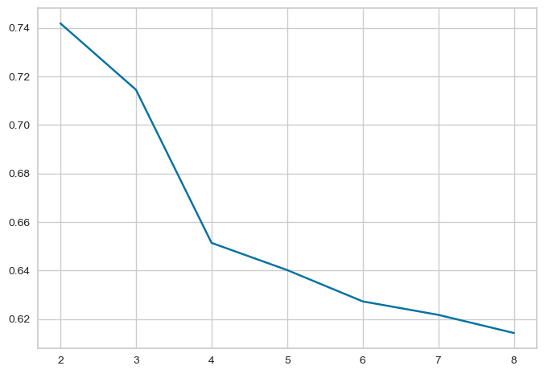

```python
#Return Silhouette Scores

sil_score = []
cluster_list = range(2, 9)
for n_clusters in cluster_list:
    clusterer = AgglomerativeClustering(n_clusters=n_clusters, affinity='euclidean', linkage='average')
    preds = clusterer.fit_predict((subsetScaled))
    score = silhouette_score(hc_df, preds)
    sil_score.append(score)
    print("For n_clusters = {}, the silhouette score is {})".format(n_clusters, score))

plt.plot(cluster_list, sil_score)
plt.show()
```

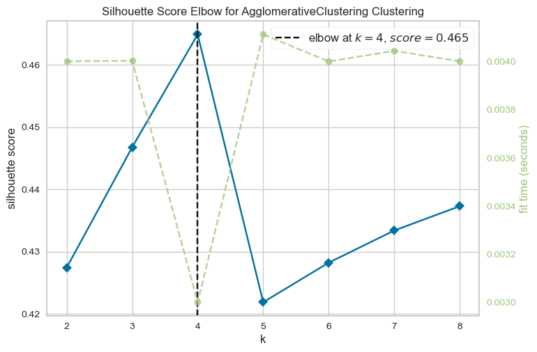

```python
#Check number of clusters from 2 through 8 using silhouette score

model = AgglomerativeClustering()
visualizer = KElbowVisualizer(model, k=(2, 9), metric="silhouette", timings=True)
visualizer.fit(hc_df)
visualizer.show()
```

### Check Dendogram for Euclidean Distance and Average Linkage

```python
Z = linkage(hc_df, metric='euclidean', method='average')
c, coph_dists = cophenet(Z , pdist(hc_df))

print('Cohpenetic correlation is ' + str(c))
```

```
Cohpenetic correlation is 0.9422540609560814
```

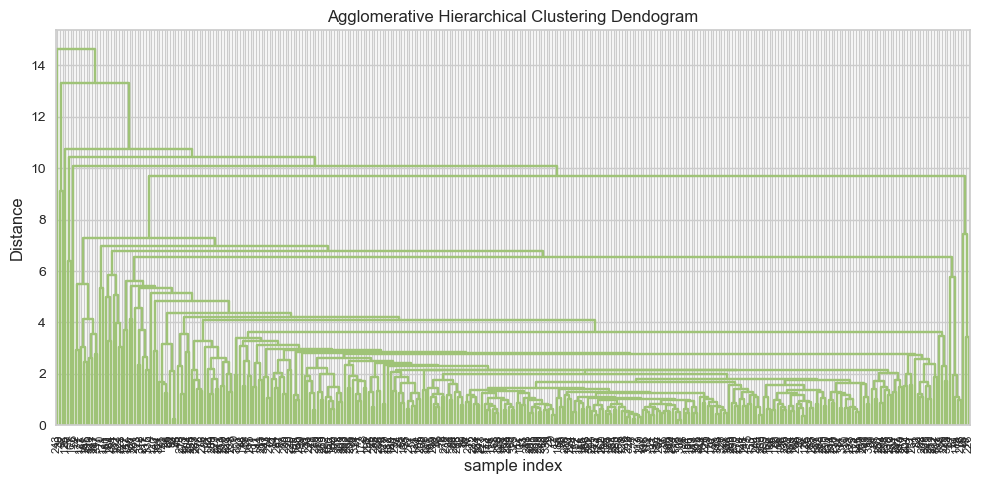

```python
plt.figure(figsize=(10, 5))
plt.title('Agglomerative Hierarchical Clustering Dendogram')
plt.xlabel('sample index')
plt.ylabel('Distance')
dendrogram(Z, leaf_rotation=90.,color_threshold = 40, leaf_font_size=8. )
plt.tight_layout()
```

#### Observations

- The greatest vertical distance is between 4 and 3 clusters
- Based on this, 3 clusters appears to be the appropriate number for Euclidean distance and Average linkage

### Create the Model with 3 Clusters

```python
#Create model with Euclidean distance and Average linkage
HCmodel = AgglomerativeClustering(n_clusters=3, affinity='euclidean', linkage='average')
HCmodel.fit(hc_df)
```

```
AgglomerativeClustering(affinity='euclidean', linkage='average', n_clusters=3)
```

```python
#Add hierarchical cluster labels to the original and scaled dataframes
hc_df['HC_segments'] = HCmodel.labels_
df2['HC_segments'] = HCmodel.labels_
```

### Cluster Profiling

```python
#Find mean of each numerical value by HC_segments
hc_cluster_profile = df2.groupby('HC_segments').mean()
```

```python
#Find number of securities per cluster and add to hc_cluster_profile
hc_cluster_profile["count_in_each_segment"] = df2.groupby('HC_segments')["Security"].count().values
```

```python
#For the three clusters, find the maximum of each of the numerical columns
hc_cluster_profile.style.highlight_max(color="lightblue", axis=0)
```

| HC_segments | Current Price | Price Change | Volatility | ROE | Cash Ratio | Net Cash Flow | Net Income | Earnings Per Share | Estimated Shares Outstanding | P/E Ratio | P/B Ratio | count_in_each_segment |
| --- | --- | --- | --- | --- | --- | --- | --- | --- | --- | --- | --- | --- |
| 0 | 77.653642 | 4.184271 | 1.515129 | 35.103858 | 69.798220 | 68662246.290801 | 1613508620.178041 | 2.900905 | 578930419.447478 | 32.466828 | -1.739711 | 337 |
| 1 | 1274.949951 | 3.190527 | 1.268340 | 29.000000 | 184.000000 | -1671386000.000000 | 2551360000.000000 | 50.090000 | 50935516.070000 | 25.453183 | -1.052429 | 1 |
| 2 | 24.485001 | -13.351992 | 3.482611 | 802.000000 | 51.000000 | -1292500000.000000 | -19106500000.000000 | -41.815000 | 519573983.250000 | 60.748608 | 1.565141 | 2 |

```python
## Companies in each cluster
for cl in df2['HC_segments'].unique():
    print("In cluster {}, the following companies are present:".format(cl))
    print(df2[df2['HC_segments'] == cl]["Security"].unique())
    print()
```

```
In cluster 0, the following companies are present:
['American Airlines Group' 'AbbVie' 'Abbott Laboratories'
 'Adobe Systems Inc' 'Analog Devices, Inc.' 'Archer-Daniels-Midland Co'
 'Alliance Data Systems' 'Ameren Corp' 'American Electric Power'
 'AFLAC Inc' 'American International Group, Inc.'
 'Apartment Investment & Mgmt' 'Assurant Inc' 'Arthur J. Gallagher & Co.'
 'Akamai Technologies Inc' 'Albemarle Corp' 'Alaska Air Group Inc'
 'Allstate Corp' 'Allegion' 'Alexion Pharmaceuticals'
 'Applied Materials Inc' 'AMETEK Inc' 'Affiliated Managers Group Inc'
 'Amgen Inc' 'Ameriprise Financial' 'American Tower Corp A'
 'Amazon.com Inc' 'AutoNation Inc' 'Anthem Inc.' 'Aon plc'
 'Anadarko Petroleum Corp' 'Amphenol Corp' 'Arconic Inc'
 'Activision Blizzard' 'AvalonBay Communities, Inc.' 'Broadcom'
 'American Water Works Company Inc' 'American Express Co' 'Boeing Company'
 'Bank of America Corp' 'Baxter International Inc.' 'BB&T Corporation'
 'Bard (C.R.) Inc.' 'Baker Hughes Inc' 'BIOGEN IDEC Inc.'
 'The Bank of New York Mellon Corp.' 'Ball Corp' 'Bristol-Myers Squibb'
 'Boston Scientific' 'BorgWarner' 'Boston Properties' 'Citigroup Inc.'
 'Caterpillar Inc.' 'Chubb Limited' 'CBRE Group'
 'Crown Castle International Corp.' 'Carnival Corp.' 'Celgene Corp.'
 'CF Industries Holdings Inc' 'Citizens Financial Group' 'Church & Dwight'
 'C. H. Robinson Worldwide' 'Charter Communications' 'CIGNA Corp.'
 'Cincinnati Financial' 'Colgate-Palmolive' 'Comerica Inc.'
 'CME Group Inc.' 'Chipotle Mexican Grill' 'Cummins Inc.' 'CMS Energy'
 'Centene Corporation' 'CenterPoint Energy' 'Capital One Financial'
 'Cabot Oil & Gas' 'The Cooper Companies' 'CSX Corp.' 'CenturyLink Inc'
 'Cognizant Technology Solutions' 'Citrix Systems' 'CVS Health'
 'Chevron Corp.' 'Concho Resources' 'Dominion Resources' 'Delta Air Lines'
 'Du Pont (E.I.)' 'Deere & Co.' 'Discover Financial Services'
 'Quest Diagnostics' 'Danaher Corp.' 'The Walt Disney Company'
 'Discovery Communications-A' 'Discovery Communications-C'
 'Delphi Automotive' 'Digital Realty Trust' 'Dun & Bradstreet'
 'Dover Corp.' 'Dr Pepper Snapple Group' 'Duke Energy' 'DaVita Inc.'
 'Devon Energy Corp.' 'eBay Inc.' 'Ecolab Inc.' 'Consolidated Edison'
 'Equifax Inc.' "Edison Int'l" 'Eastman Chemical' 'EOG Resources'
 'Equinix' 'Equity Residential' 'EQT Corporation' 'Eversource Energy'
 'Essex Property Trust, Inc.' 'E*Trade' 'Eaton Corporation'
 'Entergy Corp.' 'Edwards Lifesciences' 'Exelon Corp.' "Expeditors Int'l"
 'Expedia Inc.' 'Extra Space Storage' 'Ford Motor' 'Fastenal Co'
 'Facebook' 'Fortune Brands Home & Security' 'Freeport-McMoran Cp & Gld'
```

[output cut: 58 more lines]

```
 'Valero Energy' 'Vulcan Materials' 'Vornado Realty Trust'
 'Verisk Analytics' 'Verisign Inc.' 'Vertex Pharmaceuticals Inc'
 'Ventas Inc' 'Verizon Communications' 'Waters Corporation'
 'Wec Energy Group Inc' 'Wells Fargo' 'Whirlpool Corp.'
 'Waste Management Inc.' 'Williams Cos.' 'Western Union Co'
 'Weyerhaeuser Corp.' 'Wyndham Worldwide' 'Wynn Resorts Ltd'
 'Cimarex Energy' 'Xcel Energy Inc' 'XL Capital' 'Exxon Mobil Corp.'
 'Dentsply Sirona' 'Xerox Corp.' 'Xylem Inc.' 'Yahoo Inc.'
 'Yum! Brands Inc' 'Zimmer Biomet Holdings' 'Zions Bancorp' 'Zoetis']

In cluster 2, the following companies are present:
['Apache Corporation' 'Chesapeake Energy']

In cluster 1, the following companies are present:
['Priceline.com Inc']
```

```python
# Number of companies from each GICS Sector within each cluster
df2.groupby(['HC_segments', 'GICS Sector'])['Security'].count()
```

```
HC_segments  GICS Sector
0            Consumer Discretionary         39
             Consumer Staples               19
             Energy                         28
             Financials                     49
             Health Care                    40
             Industrials                    53
             Information Technology         33
             Materials                      20
             Real Estate                    27
             Telecommunications Services     5
             Utilities                      24
1            Consumer Discretionary          1
2            Energy                          2
Name: Security, dtype: int64
```

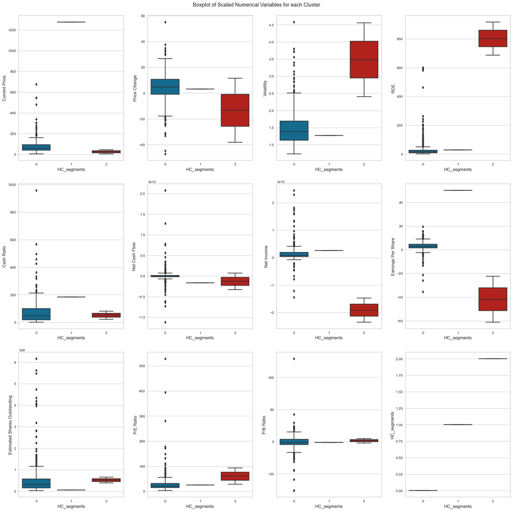

```python
#Create boxplots by cluster for numerical variables
plt.figure(figsize=(20, 20))
plt.suptitle("Boxplot of Scaled Numerical Variables for each Cluster")

# selecting numerical columns
num_col = df2.select_dtypes(include=np.number).columns.tolist()

for i, variable in enumerate(num_col):
    plt.subplot(3, 4, i + 1)
    sns.boxplot(data=df2, x="HC_segments", y=variable)

plt.tight_layout(pad=2.0)
```